# Webscraping

## Webscraping

- automatically downloading information from webpages
- useful for getting and storing large amounts of online data.

## Basic HTML

HTML (HyperText Markup Language) is the language that websites use to tell your web browser how to display and structure the content on a website. Right clicking and selecting “inspect” in most web browsers will show the HTML structure of a page.

Try it at [google.com](https://www.google.com/) you’ll see an image that looks something like this:

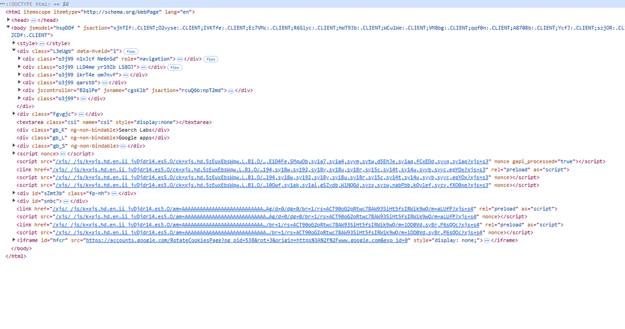

## Basic HTML

- The HTML code uses tags like `<p>some text</p>` that can be interpreted by your web browser and does stuff like control the location and appearance of text and images.
- When we’re webscraping, we’ll take advantage of that structure to extract the details we want.

## HTML

A basic page:

```html
<!DOCTYPE html>
<html>
  <head>
    <title>Page Title</title>
  </head>
  <body>

    <h1>This is a Heading</h1>
      <p>This is a paragraph.</p>
  <div>
    <p>This is a paragraph inside a divider</p>
  </div>
  <p class="custom"> This is a paragraph with a custom class</p>
    <h1 class="custom"> This is a header with a custom class</h1>
  <a href="https://www.google.com">this is a link</a>
  <a href="https://c.com">this is also a link</a>

  </body>
</html>
```

## HTML

- The first part inside the `<` is the tag. The `</a>` is the symbol that represents the end of this tag.
- `href=` is an attribute. It is generally invisible to the user but will contain some data that is used by the browser.
- “this is a link” is going to be visible to the user as text because its not inside of `<>`

**How it looks in the code:**

```html
<a href="https://www.google.com">this is a link</a>
```

**How it looks in the browser:**

[this is a link](https://www.google.com)

## HTML

- The `<a>` element is a “child” of the `<div>` tag because it is between `<div>...</div>`
- `<div>` has a class called “custom”, and a style attribute that controls the background color
- `<div>` also has an id attribute. In properly formatted HTML, the ID will always be unique to an element.

**How it looks in the code:**

```html
<div class="custom" id='bluediv' style="background-color:powderblue;"> This is a div
    <a href="https://www.google.com">this is a link</a>
<div>
```

**How it looks in the browser:**

This is a div [this is a link](https://www.google.com)

## Navigating the tree

- Actual HTML data is complex, but we’ll use tags, classes, IDs and other attributes to pluck out the pieces of data we want and put it in a structured format.
- We’ve got three options for writing code to extract HTML elements:
  - Xpath expressions
  - CSS selectors
  - BeautifulSoup (specific to a python package)
- We’ll touch on XPath but we’ll primarily use CSS selectors/Beautiful Soup

# Example

We want to get a list of headlines and links from lite.cnn.com, a simplified version of CNNs home page for people with slow internet connections

[figure not shown]

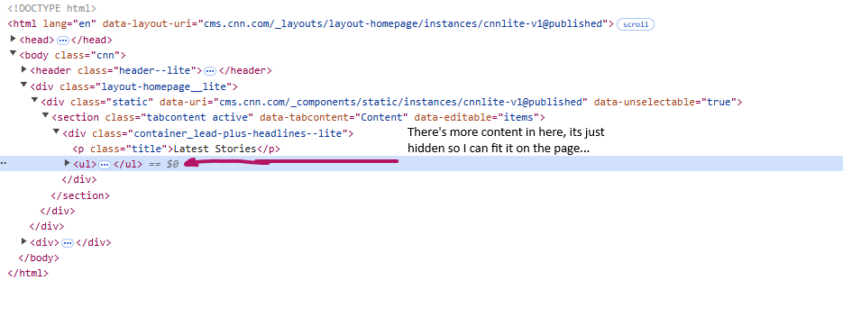

## Getting data

- Downloading the HTML just requires to use `get`
- `BeautifulSoup` will parse the result into a Python object

```python
from bs4 import BeautifulSoup
from requests import get
import pandas as pd

page = get('https://lite.cnn.com/')
soup = BeautifulSoup(page.content, 'html.parser')
```

## Tag selection

`soup.select("x")` where `x` is a CSS selector statement.

So this code will get everything inside an “a” tag (usually a hyperlink):

```python
soup.select("a")[:3]
```

```
[<a class="title" href="/">CNN</a>, <a href="/2025/10/07/entertainment/george-clooney-raising-kids-hollywood-intl-scli">
        George Clooney says he was ‘worried’ about raising his children in Hollywood
    </a>, <a href="/2025/10/07/health/conversion-therapy-court">
        A discredited therapy for gay and trans youth is at the center of a Supreme Court case. Here’s what to know
    </a>]
```

## CSS selection

I’m getting some stuff I don’t want. There’s a “footer” here that includes links to policies and legal stuff (left image), but the content I want is inside of `ul` tags (right image)

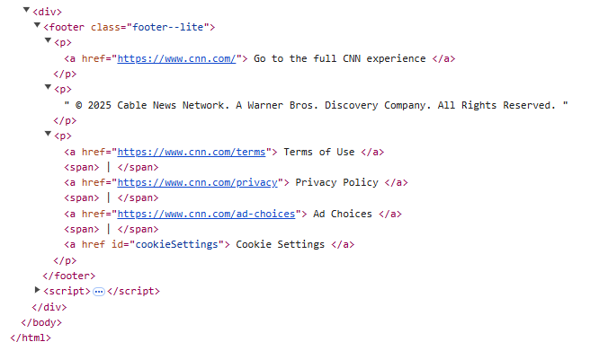

The stuff we want to exclude =

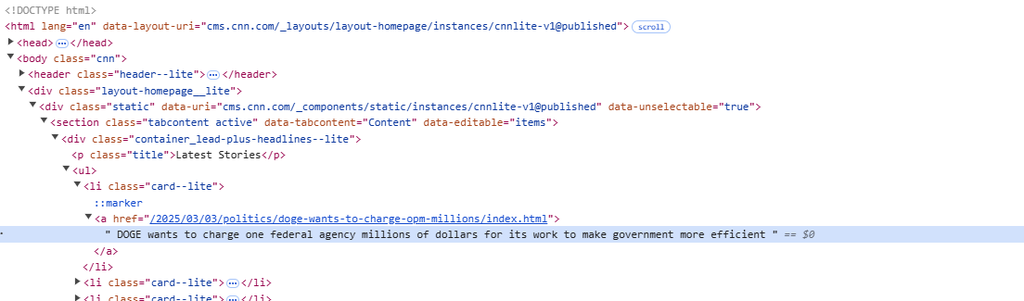

The stuff we want

# CSS selection

So we can select only `<a>` tags that are inside of a `<ul>` tag like this:

```python
soup.select("ul a")[:5]
```

```
[<a href="/2025/10/07/entertainment/george-clooney-raising-kids-hollywood-intl-scli">
        George Clooney says he was ‘worried’ about raising his children in Hollywood
    </a>, <a href="/2025/10/07/health/conversion-therapy-court">
        A discredited therapy for gay and trans youth is at the center of a Supreme Court case. Here’s what to know
    </a>, <a href="/2025/10/07/health/covid-19-vaccine-free-health-insurance">
        Most Americans are still guaranteed to get Covid-19 vaccines at no cost — for now
    </a>, <a href="/2025/10/06/weather/tropical-storm-jerry-track-path-climate">
        A new tropical storm could form in the Atlantic this week as hurricane season shows no signs of stopping
    </a>, <a href="/2025/10/06/entertainment/being-mean-to-taylor-swift">
        Finally, everyone can say bad things about Taylor Swift
    </a>]
```

# CSS selection

Finally, we can extract the `href` attribute value by using the `get(x)` method, where `x` is the name of an attribute:

```python
soup.select("ul a")[0].get("href")
```

```
'/2025/10/07/entertainment/george-clooney-raising-kids-hollywood-intl-scli'
```

And we’ll select the text using `get_text`

```python
soup.select("ul a")[0].get_text()
```

```
'\n        George Clooney says he was ‘worried’ about raising his children in Hollywood\n    '
```

# CSS selection

The urls here are “relative urls”, which means we need to paste the url of the current page on to them to make them work properly. I can do this in a list comprehension:

```python
urls = ['https://lite.cnn.com' + i.get("href") for i in  soup.select("ul a")]
```

And I also might want to use `.strip()` on the headlines to get rid of some extraneous spacing:

```python
headlines = [i.get_text().strip() for i in  soup.select("ul a")]
```

# CSS selection

```python
pd.DataFrame({'urls': urls,  'headlines': headlines})
```

```
                                                 urls                                          headlines
0   https://lite.cnn.com/2025/10/07/entertainment/...  George Clooney says he was ‘worried’ about rai...
1   https://lite.cnn.com/2025/10/07/health/convers...  A discredited therapy for gay and trans youth ...
2   https://lite.cnn.com/2025/10/07/health/covid-1...  Most Americans are still guaranteed to get Cov...
3   https://lite.cnn.com/2025/10/06/weather/tropic...  A new tropical storm could form in the Atlanti...
4   https://lite.cnn.com/2025/10/06/entertainment/...  Finally, everyone can say bad things about Tay...
..                                                ...                                                ...
95  https://lite.cnn.com/2025/10/05/americas/ecuad...  Protesters rally in Quito as Ecuador declares ...
96  https://lite.cnn.com/2025/10/05/politics/man-a...  Man arrested and charged with possessing explo...
97  https://lite.cnn.com/2025/10/05/europe/macron-...  Macron loyalist Roland Lescure named France’s ...
98  https://lite.cnn.com/2025/10/05/americas/mexic...  Mexico soccer star Omar Bravo arrested on susp...
99  https://lite.cnn.com/2025/10/05/sport/football...  Minnesota Vikings edge Cleveland Browns with l...

[100 rows x 2 columns]
```

# Other selector expressions

- Use “[tagname].[classname] to get elements with a specific class. For instance, only `<p>` tags with the class `title` :

```python
soup.select("p.title")
```

```
[<p class="title">Latest Stories</p>]
```

# Other selector expressions

- Use [tagname]#[id] to get elements with a particular ID. Example all `<a>` tags with `#cookieSettings` ID:

```python
soup.select("a#cookieSettings")
```

```
[<a href="" id="cookieSettings">
      Cookie Settings
    </a>]
```

You can also leave the tag name out to get **any** tag with a particular ID or class:

```python
soup.select("#cookieSettings")
```

```
[<a href="" id="cookieSettings">
      Cookie Settings
    </a>]
```

# Other selector expressions

Use `[attributename = "attributevalue"]` to select based on attributes other than classes or IDs.

This code gives me the first `a` tag that is inside of a tag that has `data-tabcontent="Content"` (you don’t need to know what this means! You just need to know that it gets you the data you want.

```python
soup.select('[data-tabcontent="Content"] a')[0]
```

```
<a href="/2025/10/07/entertainment/george-clooney-raising-kids-hollywood-intl-scli">
        George Clooney says he was ‘worried’ about raising his children in Hollywood
    </a>
```

# Other selector expressions

Use `select_one` to just get the first element that matches a selection

```python
soup.select_one('[data-tabcontent="Content"] a')
```

```
<a href="/2025/10/07/entertainment/george-clooney-raising-kids-hollywood-intl-scli">
        George Clooney says he was ‘worried’ about raising his children in Hollywood
    </a>
```

# Other selector expressions

Keep in mind that the data is nested, so you get all of the things that are inside of whatever you select. So this expression gets the `footer` tag all of its descendants, which include multiple `<a>` tags in a single result:

```python
soup.select('footer')
```

[output not shown]

# Other selector expressions

By contrast, this gives you a list of `a` tags instead of just one element:

```python
soup.select('footer a')
```

```
[<a href="https://www.cnn.com/">
      Go to the full CNN experience
    </a>, <a href="https://www.cnn.com/terms">
      Terms of Use
    </a>, <a href="https://www.cnn.com/privacy">
      Privacy Policy
    </a>, <a href="https://www.cnn.com/ad-choices">
      Ad Choices
    </a>, <a href="" id="cookieSettings">
      Cookie Settings
    </a>]
```

# Steps

1. Identify the data you want to extract
2. Identify a CSS selector that isolates that element (start with the tag and work backwards until you find an expression that only gets the stuff you want)
3. Loop through the selection and use `get` or `get_text` to grab attributes or text
4. Put the results in a data frame